# Analysis of the ETH Zurich data

Based on work by George Kinnear

21/05/2020

```r
library(mirt)      # For IRT analysis
library(psych)     # For factor analysis
library(tidyverse) # For data wrangling and visualisation
library(reshape)   # For reshaping nested lists
library(vroom)     # For reading in many files at once
library(broom)     # For tidying model output
library(fs)        # For file system operations
library(gt)        # For formatting tables
library(knitr)     # For markdown tables
library(ggrepel)   # For labelling points without overlap
library(skimr)     # For data frame level summary
library(ggridges)  # For ridge plots
```

## Packages

We will use the following packages in this analysis:

- [**mirt**](https://cran.r-project.org/web/packages/mirt/mirt.pdf): For IRT analysis
- [**psych**](https://personality-project.org/r/psych/): For factor analysis
- [**tidyverse**](https://tidyverse.org/): For data wrangling and visualisation
- [**reshape**](http://had.co.nz/reshape/): For reshaping nested lists
- [**vroom**](https://vroom.r-lib.org/): For reading in many files at once
- [**broom**](https://broom.tidymodels.org/): For tidying model output
- [**fs**](https://fs.r-lib.org/): For file system operations
- [**gt**](https://gt.rstudio.com/): For formatting tables
- [**knitr**](https://yihui.org/knitr/): For markdown tables
- [**ggrepel**](https://ggrepel.slowkow.com/): For labelling points without overlap
- [**skimr**](https://docs.ropensci.org/skimr/): For data frame level summary
- [**ggridges**](https://wilkelab.org/ggridges/): For ridge plots

## Data

Load the data from the two years and bind them to create a single data frame:

```r
# load data
eth_2018 <- read_csv("data/2018/all.csv")
eth_2017 <- read_csv("data/2017/all.csv")

# add year as the identifier column to each data frame
eth_2018 <- eth_2018 %>%
  mutate(year = 2018)
eth_2017 <- eth_2017 %>%
  mutate(year = 2017)

# bind the two data frames together
eth <- bind_rows(eth_2017, eth_2018) %>%
  relocate(year)
```

Skim an overview of the data:

```r
skim(eth) %>% kable()
```

| skim_type | skim_variable | n_missing | complete_rate | numeric.mean | numeric.sd | numeric.p0 | numeric.p25 | numeric.p50 | numeric.p75 | numeric.p100 | numeric.hist |
| --- | --- | --- | --- | --- | --- | --- | --- | --- | --- | --- | --- |
| numeric | year | 0 | 1 | 2017.5086232 | 0.4999987 | 2017 | 2017 | 2018 | 2018 | 2018 | ▇▁▁▁▇ |
| numeric | A1 | 0 | 1 | 0.9517685 | 0.2142864 | 0 | 1 | 1 | 1 | 1 | ▁▁▁▁▇ |
| numeric | A2 | 0 | 1 | 0.2934814 | 0.4554237 | 0 | 0 | 0 | 1 | 1 | ▇▁▁▁▃ |
| numeric | A3 | 0 | 1 | 0.6331482 | 0.4820160 | 0 | 0 | 1 | 1 | 1 | ▅▁▁▁▇ |
| numeric | A4 | 0 | 1 | 0.6337328 | 0.4818541 | 0 | 0 | 1 | 1 | 1 | ▅▁▁▁▇ |
| numeric | A5 | 0 | 1 | 0.4793920 | 0.4996482 | 0 | 0 | 0 | 1 | 1 | ▇▁▁▁▇ |
| numeric | A6 | 0 | 1 | 0.7202572 | 0.4489384 | 0 | 0 | 1 | 1 | 1 | ▃▁▁▁▇ |
| numeric | A7 | 0 | 1 | 0.7065186 | 0.4554237 | 0 | 0 | 1 | 1 | 1 | ▃▁▁▁▇ |
| numeric | A8 | 0 | 1 | 0.4849459 | 0.4998464 | 0 | 0 | 0 | 1 | 1 | ▇▁▁▁▇ |
| numeric | A9 | 0 | 1 | 0.4612686 | 0.4985705 | 0 | 0 | 0 | 1 | 1 | ▇▁▁▁▇ |
| numeric | A10 | 0 | 1 | 0.5422391 | 0.4982855 | 0 | 0 | 1 | 1 | 1 | ▇▁▁▁▇ |
| numeric | A11 | 0 | 1 | 0.5784858 | 0.4938737 | 0 | 0 | 1 | 1 | 1 | ▆▁▁▁▇ |
| numeric | A12 | 0 | 1 | 0.6968723 | 0.4596771 | 0 | 0 | 1 | 1 | 1 | ▃▁▁▁▇ |
| numeric | A13 | 0 | 1 | 0.3656825 | 0.4816914 | 0 | 0 | 0 | 1 | 1 | ▇▁▁▁▅ |
| numeric | A14 | 0 | 1 | 0.5667933 | 0.4955910 | 0 | 0 | 1 | 1 | 1 | ▆▁▁▁▇ |
| numeric | A15 | 0 | 1 | 0.4615609 | 0.4985931 | 0 | 0 | 0 | 1 | 1 | ▇▁▁▁▇ |
| numeric | A16 | 0 | 1 | 0.1935107 | 0.3951075 | 0 | 0 | 0 | 0 | 1 | ▇▁▁▁▂ |
| numeric | A17 | 0 | 1 | 0.5960246 | 0.4907644 | 0 | 0 | 1 | 1 | 1 | ▆▁▁▁▇ |
| numeric | A18 | 0 | 1 | 0.3724057 | 0.4835163 | 0 | 0 | 0 | 1 | 1 | ▇▁▁▁▅ |
| numeric | A19 | 0 | 1 | 0.3469746 | 0.4760772 | 0 | 0 | 0 | 1 | 1 | ▇▁▁▁▅ |
| numeric | A20 | 0 | 1 | 0.7240573 | 0.4470534 | 0 | 0 | 1 | 1 | 1 | ▃▁▁▁▇ |
| numeric | A21 | 0 | 1 | 0.5150541 | 0.4998464 | 0 | 0 | 1 | 1 | 1 | ▇▁▁▁▇ |
| numeric | A22 | 0 | 1 | 0.5171003 | 0.4997805 | 0 | 0 | 1 | 1 | 1 | ▇▁▁▁▇ |
| numeric | A23 | 0 | 1 | 0.4223911 | 0.4940123 | 0 | 0 | 0 | 1 | 1 | ▇▁▁▁▆ |
| numeric | A24 | 0 | 1 | 0.5822859 | 0.4932547 | 0 | 0 | 1 | 1 | 1 | ▆▁▁▁▇ |
| numeric | A25 | 0 | 1 | 0.6381175 | 0.4806153 | 0 | 0 | 1 | 1 | 1 | ▅▁▁▁▇ |
| numeric | A26 | 0 | 1 | 0.8018123 | 0.3986926 | 0 | 1 | 1 | 1 | 1 | ▂▁▁▁▇ |
| numeric | A27 | 0 | 1 | 0.3957907 | 0.4890913 | 0 | 0 | 0 | 1 | 1 | ▇▁▁▁▅ |
| numeric | A28 | 0 | 1 | 0.4387606 | 0.4963081 | 0 | 0 | 0 | 1 | 1 | ▇▁▁▁▆ |
| numeric | A29 | 0 | 1 | 0.5007308 | 0.5000726 | 0 | 0 | 1 | 1 | 1 | ▇▁▁▁▇ |
| numeric | A30 | 0 | 1 | 0.7430576 | 0.4370113 | 0 | 0 | 1 | 1 | 1 | ▃▁▁▁▇ |
| numeric | A31 | 0 | 1 | 0.3735750 | 0.4838235 | 0 | 0 | 0 | 1 | 1 | ▇▁▁▁▅ |
| numeric | A32 | 0 | 1 | 0.2151418 | 0.4109807 | 0 | 0 | 0 | 0 | 1 | ▇▁▁▁▂ |
| numeric | A33 | 0 | 1 | 0.7699503 | 0.4209259 | 0 | 1 | 1 | 1 | 1 | ▂▁▁▁▇ |
| numeric | A34 | 0 | 1 | 0.5983631 | 0.4903009 | 0 | 0 | 1 | 1 | 1 | ▆▁▁▁▇ |
| numeric | A35 | 0 | 1 | 0.3285589 | 0.4697579 | 0 | 0 | 0 | 1 | 1 | ▇▁▁▁▃ |
| numeric | A36 | 0 | 1 | 0.2244958 | 0.4173108 | 0 | 0 | 0 | 0 | 1 | ▇▁▁▁▂ |

## Multidimensional Item Response Theory

Fit the Multidimensional Item Response Theory (mirt) model. From the function definition:

[output not shown]

```r
fit_2pl <- mirt(
  data = eth[2:37],  # all but the year column
  model = 1,         # number of factors to extract
  itemtype = "2PL",  # 2 parameter logistic model
  SE = TRUE          # estimate standard errors
  )
```

```
##
Iteration: 1, Log-Lik: -66428.235, Max-Change: 0.72929
Iteration: 2, Log-Lik: -65241.884, Max-Change: 0.24383
Iteration: 3, Log-Lik: -65081.725, Max-Change: 0.14895
Iteration: 4, Log-Lik: -65014.543, Max-Change: 0.11122
Iteration: 5, Log-Lik: -64977.384, Max-Change: 0.09454
Iteration: 6, Log-Lik: -64955.545, Max-Change: 0.06530
Iteration: 7, Log-Lik: -64942.861, Max-Change: 0.06130
Iteration: 8, Log-Lik: -64935.381, Max-Change: 0.04421
Iteration: 9, Log-Lik: -64930.611, Max-Change: 0.03616
Iteration: 10, Log-Lik: -64927.669, Max-Change: 0.02949
Iteration: 11, Log-Lik: -64925.871, Max-Change: 0.01790
Iteration: 12, Log-Lik: -64924.788, Max-Change: 0.01302
Iteration: 13, Log-Lik: -64922.989, Max-Change: 0.00234
Iteration: 14, Log-Lik: -64922.963, Max-Change: 0.00196
Iteration: 15, Log-Lik: -64922.949, Max-Change: 0.00172
Iteration: 16, Log-Lik: -64922.930, Max-Change: 0.00086
Iteration: 17, Log-Lik: -64922.925, Max-Change: 0.00094
Iteration: 18, Log-Lik: -64922.922, Max-Change: 0.00077
Iteration: 19, Log-Lik: -64922.912, Max-Change: 0.00018
Iteration: 20, Log-Lik: -64922.912, Max-Change: 0.00019
Iteration: 21, Log-Lik: -64922.912, Max-Change: 0.00018
Iteration: 22, Log-Lik: -64922.910, Max-Change: 0.00011
Iteration: 23, Log-Lik: -64922.910, Max-Change: 0.00010
Iteration: 24, Log-Lik: -64922.910, Max-Change: 0.00010
##
## Calculating information matrix...
```

Compute factor score estimates and augment the existing data frame using the `fscores()` function from the mirt package which takes in a computed model object and computes factor score estimates according to the method specified.

```r
eth <- eth %>%
  mutate(F1 = fscores(fit_2pl, method = "EAP"))
```

Calculate the model coefficient estimates using a generic function `coef()` which is used to extract model coefficients from objects returned by modeling functions. We’re also setting the `IRTpars` argument to `TRUE`, which means slope intercept parameters will be converted into traditional IRT parameters.

```r
coefs_2pl <- coef(fit_2pl, IRTpars = TRUE)
```

The resulting object `coefs` is a list, with one element for each question, and an additional `GroupPars` element that we won’t be using.

```r
coefs_2pl
```

```
## $A1
##             a      b  g  u
## par     1.201 -2.990  0  1
## CI_2.5  1.006 -3.357 NA NA
## CI_97.5 1.396 -2.624 NA NA
##
## $A2
##             a     b  g  u
## par     0.562 1.673  0  1
## CI_2.5  0.476 1.407 NA NA
## CI_97.5 0.648 1.938 NA NA
##
## $A3
##             a      b  g  u
## par     1.348 -0.543  0  1
## CI_2.5  1.230 -0.617 NA NA
## CI_97.5 1.467 -0.468 NA NA
##
## $A4
##             a      b  g  u
## par     1.177 -0.592  0  1
## CI_2.5  1.068 -0.675 NA NA
## CI_97.5 1.286 -0.509 NA NA
##
## $A5
##             a     b  g  u
## par     1.462 0.079  0  1
## CI_2.5  1.340 0.015 NA NA
## CI_97.5 1.584 0.143 NA NA
##
## $A6
##             a      b  g  u
## par     1.553 -0.864  0  1
## CI_2.5  1.416 -0.943 NA NA
## CI_97.5 1.690 -0.785 NA NA
##
## $A7
##             a      b  g  u
## par     1.281 -0.896  0  1
## CI_2.5  1.162 -0.986 NA NA
```

[output cut: 166 more lines]

```
## par     1.276 0.732  0  1
## CI_2.5  1.160 0.649 NA NA
## CI_97.5 1.393 0.816 NA NA
##
## $A36
##             a     b  g  u
## par     1.246 1.276  0  1
## CI_2.5  1.122 1.161 NA NA
## CI_97.5 1.369 1.391 NA NA
##
## $GroupPars
##         MEAN_1 COV_11
## par          0      1
## CI_2.5      NA     NA
## CI_97.5     NA     NA
```

Let’s take a closer look at the first element:

```r
coefs_2pl[1]
```

```
## $A1
##                a         b  g  u
## par     1.200868 -2.990220  0  1
## CI_2.5  1.005934 -3.356706 NA NA
## CI_97.5 1.395802 -2.623733 NA NA
```

In this output:

- `a` is discrimination
- `b` is difficulty
- endpoints of the 95% confidence intervals are also shown

To make this output a little more user friendly, we should tidy it such that we have a row per question. We’ll do this in two steps. First, write a function that tidies the output for one question, i.e. one list element. Then, map this function over the list of all questions, resulting in a data frame.

```r
tidy_mirt_coefs <- function(x){
  x %>%
    # melt the list element
    melt() %>%
    # convert to a tibble
    as_tibble() %>%
    # convert factors to characters
    mutate(across(where(is.factor), as.character)) %>%
    # only focus on rows where X2 is a or b (discrimination or difficulty)
    filter(X2 %in% c("a", "b")) %>%
    # in X1, relabel par (parameter) as est (estimate)
    mutate(X1 = if_else(X1 == "par", "est", X1)) %>%
    # unite columns X2 and X1 into a new column called var separated by _
    unite(X2, X1, col = "var", sep = "_") %>%
    # turn into a wider data frame
    pivot_wider(names_from = var, values_from = value)
}
```

Let’s see what this does to a single element in `coefs`:

```r
tidy_mirt_coefs(coefs_2pl[1])
```

```
## # A tibble: 1 x 7
##   L1    a_est a_CI_2.5 a_CI_97.5 b_est b_CI_2.5 b_CI_97.5
##   <chr> <dbl>    <dbl>     <dbl> <dbl>    <dbl>     <dbl>
## 1 A1     1.20     1.01      1.40 -2.99    -3.36     -2.62
```

And now let’s map it over all 36 elements of coefs:

```r
tidy_2pl <- map_dfr(coefs_2pl[1:36], tidy_mirt_coefs, .id = "Question")
```

A quick peek at the result:

```r
tidy_2pl
```

```
## # A tibble: 36 x 7
##    Question a_est a_CI_2.5 a_CI_97.5   b_est b_CI_2.5 b_CI_97.5
##    <chr>    <dbl>    <dbl>     <dbl>   <dbl>    <dbl>     <dbl>
##  1 A1       1.20     1.01      1.40  -2.99   -3.36      -2.62
##  2 A2       0.562    0.476     0.648  1.67    1.41       1.94
##  3 A3       1.35     1.23      1.47  -0.543  -0.617     -0.468
##  4 A4       1.18     1.07      1.29  -0.592  -0.675     -0.509
##  5 A5       1.46     1.34      1.58   0.0787  0.0147     0.143
##  6 A6       1.55     1.42      1.69  -0.864  -0.943     -0.785
##  7 A7       1.28     1.16      1.40  -0.896  -0.986     -0.805
##  8 A8       1.16     1.05      1.27   0.0659 -0.00750    0.139
##  9 A9       2.02     1.86      2.18   0.127   0.0723     0.182
## 10 A10      1.76     1.62      1.90  -0.147  -0.206     -0.0886
## # … with 26 more rows
```

And a nicely formatted table of the result:

```r
gt(tidy_2pl) %>%
  fmt_number(columns = contains("_"), decimals = 3) %>%
  data_color(
    columns = contains("a_"),
    colors = scales::col_numeric(palette = c("Greens"), domain = NULL)
  ) %>%
  data_color(
    columns = contains("b_"),
    colors = scales::col_numeric(palette = c("Blues"), domain = NULL)
  ) %>%
  tab_spanner(label = "Discrimination", columns = contains("a_")) %>%
  tab_spanner(label = "Difficulty", columns = contains("b_")) %>%
  cols_label(
    a_est = "Est.",
    b_est = "Est.",
    a_CI_2.5 = "2.5%",
    b_CI_2.5 = "2.5%",
    a_CI_97.5 = "97.5%",
    b_CI_97.5 = "97.5%"
  )
```

| Question | Discrimination Est. | Discrimination 2.5% | Discrimination 97.5% | Difficulty Est. | Difficulty 2.5% | Difficulty 97.5% |
| --- | --- | --- | --- | --- | --- | --- |
| A1 | 1.201 | 1.006 | 1.396 | −2.990 | −3.357 | −2.624 |
| A2 | 0.562 | 0.476 | 0.648 | 1.673 | 1.407 | 1.938 |
| A3 | 1.348 | 1.230 | 1.467 | −0.543 | −0.617 | −0.468 |
| A4 | 1.177 | 1.068 | 1.286 | −0.592 | −0.675 | −0.509 |
| A5 | 1.462 | 1.340 | 1.584 | 0.079 | 0.015 | 0.143 |
| A6 | 1.553 | 1.416 | 1.690 | −0.864 | −0.943 | −0.785 |
| A7 | 1.281 | 1.162 | 1.400 | −0.896 | −0.986 | −0.805 |
| A8 | 1.160 | 1.055 | 1.265 | 0.066 | −0.007 | 0.139 |
| A9 | 2.017 | 1.856 | 2.178 | 0.127 | 0.072 | 0.182 |
| A10 | 1.762 | 1.620 | 1.904 | −0.147 | −0.206 | −0.089 |
| A11 | 1.678 | 1.540 | 1.815 | −0.281 | −0.342 | −0.220 |
| A12 | 0.886 | 0.789 | 0.984 | −1.092 | −1.223 | −0.960 |
| A13 | 0.716 | 0.628 | 0.803 | 0.856 | 0.718 | 0.994 |
| A14 | 1.433 | 1.312 | 1.554 | −0.259 | −0.325 | −0.193 |
| A15 | 0.848 | 0.757 | 0.938 | 0.210 | 0.117 | 0.303 |
| A16 | 1.544 | 1.396 | 1.693 | 1.291 | 1.189 | 1.392 |
| A17 | 1.221 | 1.111 | 1.331 | −0.411 | −0.487 | −0.335 |
| A18 | 1.234 | 1.122 | 1.347 | 0.547 | 0.468 | 0.626 |
| A19 | 1.309 | 1.191 | 1.427 | 0.639 | 0.560 | 0.718 |
| A20 | 2.318 | 2.119 | 2.518 | −0.741 | −0.802 | −0.679 |
| A21 | 2.143 | 1.973 | 2.313 | −0.048 | −0.102 | 0.005 |
| A22 | 1.996 | 1.837 | 2.154 | −0.056 | −0.111 | −0.001 |
| A23 | 1.874 | 1.723 | 2.025 | 0.264 | 0.206 | 0.322 |
| A24 | 1.433 | 1.311 | 1.554 | −0.320 | −0.387 | −0.253 |
| A25 | 0.530 | 0.449 | 0.612 | −1.139 | −1.347 | −0.930 |
| A26 | 2.418 | 2.193 | 2.642 | −1.042 | −1.112 | −0.972 |
| A27 | 2.000 | 1.838 | 2.162 | 0.347 | 0.290 | 0.404 |
| A28 | 1.859 | 1.709 | 2.008 | 0.209 | 0.151 | 0.266 |
| A29 | 0.912 | 0.819 | 1.005 | −0.004 | −0.090 | 0.083 |
| A30 | 1.258 | 1.137 | 1.379 | −1.091 | −1.193 | −0.988 |
| A31 | 1.255 | 1.142 | 1.368 | 0.537 | 0.459 | 0.614 |
| A32 | 1.607 | 1.457 | 1.757 | 1.151 | 1.060 | 1.242 |
| A33 | 0.932 | 0.825 | 1.038 | −1.518 | −1.680 | −1.355 |
| A34 | 0.906 | 0.811 | 1.000 | −0.517 | −0.614 | −0.420 |
| A35 | 1.276 | 1.160 | 1.393 | 0.732 | 0.649 | 0.816 |
| A36 | 1.246 | 1.122 | 1.369 | 1.276 | 1.161 | 1.391 |

### Comparing across years

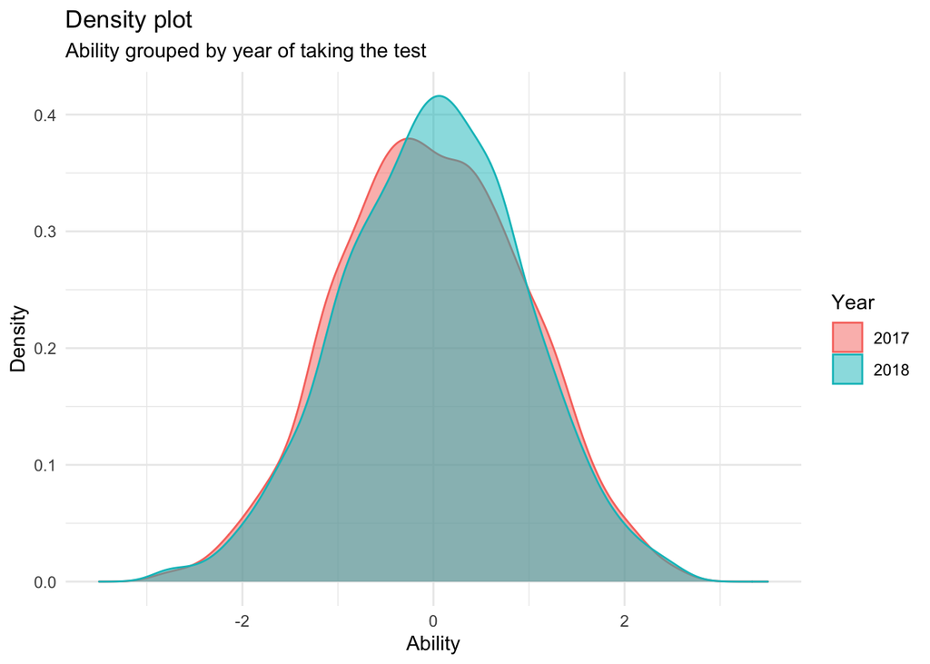

```r
ggplot(eth, aes(F1, fill = as.factor(year), colour = as.factor(year))) +
  geom_density(alpha=0.5) +
  scale_x_continuous(limits = c(-3.5,3.5)) +
  labs(title = "Density plot",
       subtitle = "Ability grouped by year of taking the test",
       x = "Ability", y = "Density",
       fill = "Year", colour = "Year") +
  theme_minimal()
```

## Factor analysis

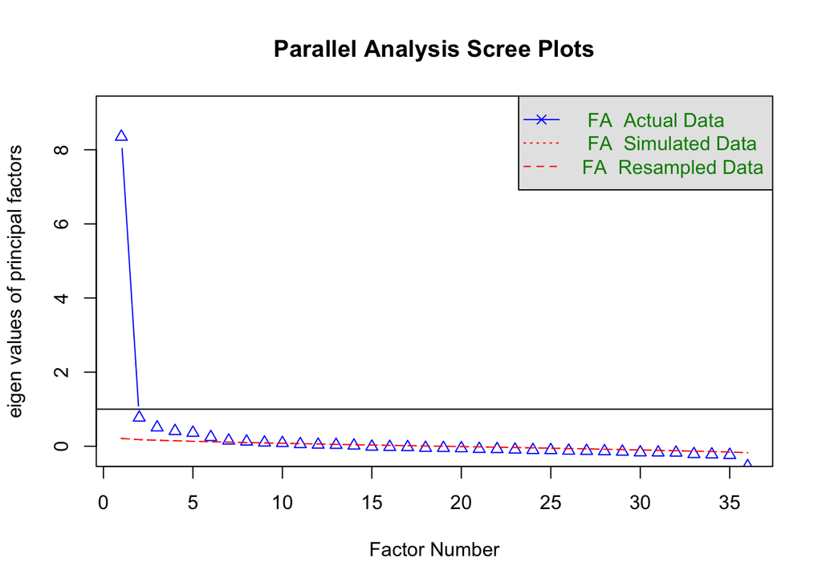

```
## Parallel analysis suggests that the number of factors =  10  and the number of components =  NA
```

```r
fa.parallel(eth[2:37], fa = "fa")
```

### 1 Factor

```r
fitfact <- factanal(eth[2:37], 1, rotation = "varimax")
print(fitfact, digits = 2, cutoff = 0.3, sort = TRUE)
```

```
##
## Call:
## factanal(x = eth[2:37], factors = 1, rotation = "varimax")
##
## Uniquenesses:
##   A1   A2   A3   A4   A5   A6   A7   A8   A9  A10  A11  A12  A13  A14  A15  A16
## 0.95 0.95 0.75 0.79 0.72 0.74 0.79 0.79 0.61 0.66 0.67 0.88 0.91 0.73 0.87 0.81
##  A17  A18  A19  A20  A21  A22  A23  A24  A25  A26  A27  A28  A29  A30  A31  A32
## 0.78 0.78 0.78 0.63 0.59 0.61 0.64 0.73 0.94 0.69 0.63 0.64 0.85 0.81 0.78 0.78
##  A33  A34  A35  A36
## 0.88 0.86 0.79 0.84
##
## Loadings:
##  [1] 0.53 0.51 0.62 0.59 0.57 0.52 0.61 0.64 0.62 0.60 0.52 0.56 0.61 0.60
## [16]      0.50 0.45 0.46 0.46 0.35 0.31 0.36 0.44 0.47 0.46 0.47      0.39 0.44
## [31] 0.47 0.47 0.34 0.38 0.46 0.40
##
##                Factor1
## SS loadings       8.35
## Proportion Var    0.23
##
## Test of the hypothesis that 1 factor is sufficient.
## The chi square statistic is 5428.36 on 594 degrees of freedom.
## The p-value is 0
```

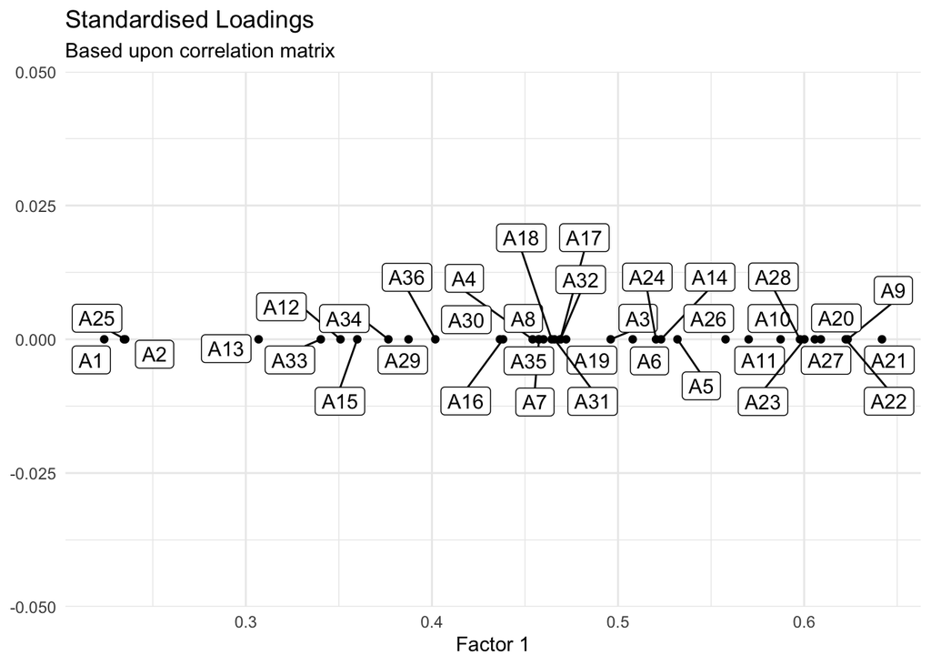

```r
load <- tidy(fitfact)

ggplot(load, aes(x = fl1, y = 0)) +
  geom_point() +
  geom_label_repel(aes(label = paste0("A", rownames(load))), show.legend = FALSE) +
  labs(x = "Factor 1", y = NULL,
       title = "Standardised Loadings",
       subtitle = "Based upon correlation matrix") +
  theme_minimal()
```

### 2 Factors

```r
fitfact <- factanal(eth[2:37], 2, rotation = "varimax")
print(fitfact, digits = 2, cutoff = 0.3, sort = TRUE)
```

```
##
## Call:
## factanal(x = eth[2:37], factors = 2, rotation = "varimax")
##
## Uniquenesses:
##   A1   A2   A3   A4   A5   A6   A7   A8   A9  A10  A11  A12  A13  A14  A15  A16
## 0.95 0.94 0.75 0.79 0.72 0.74 0.78 0.79 0.61 0.66 0.67 0.88 0.90 0.73 0.87 0.81
##  A17  A18  A19  A20  A21  A22  A23  A24  A25  A26  A27  A28  A29  A30  A31  A32
## 0.77 0.40 0.04 0.63 0.59 0.61 0.64 0.72 0.94 0.69 0.63 0.64 0.85 0.80 0.78 0.78
##  A33  A34  A35  A36
## 0.88 0.86 0.79 0.84
##
## Loadings:
##     Factor1 Factor2
## A9  0.60
## A10 0.55
## A11 0.56
## A20 0.58
## A21 0.59
## A22 0.59
## A23 0.58
## A24 0.51
## A26 0.53
## A27 0.58
## A28 0.57
## A18         0.75
## A19         0.97
## A1
## A2
## A3  0.47
## A4  0.44
## A5  0.50
## A6  0.49
## A7  0.46
## A8  0.42
## A12 0.33
## A13 0.30
## A14 0.48
## A15 0.36
## A16 0.38
## A17 0.46
## A25
## A29 0.36
## A30 0.44
## A31 0.45
## A32 0.43
## A33 0.34
## A34 0.36
## A35 0.42
## A36 0.38
##
##                Factor1 Factor2
## SS loadings       7.25    2.29
## Proportion Var    0.20    0.06
## Cumulative Var    0.20    0.27
##
## Test of the hypothesis that 2 factors are sufficient.
## The chi square statistic is 3050.55 on 559 degrees of freedom.
## The p-value is 0
```

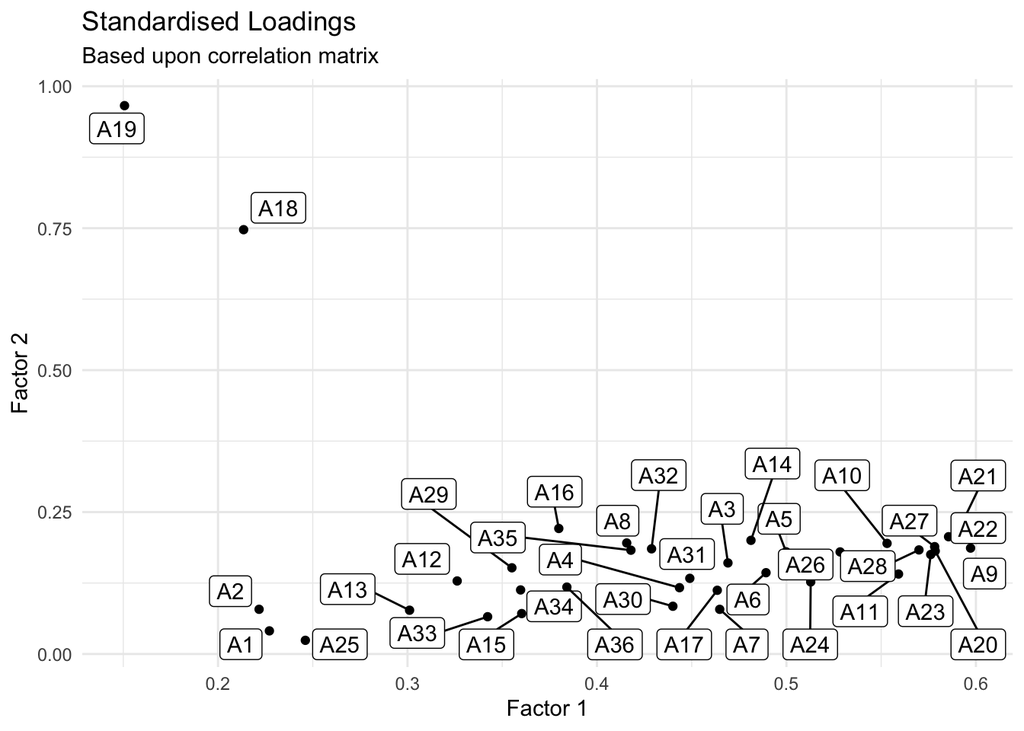

```r
load <- tidy(fitfact)

ggplot(load, aes(x = fl1, y = fl2)) +
  geom_point() +
  geom_label_repel(aes(label = paste0("A", rownames(load))), show.legend = FALSE) +
  labs(x = "Factor 1", y = "Factor 2",
       title = "Standardised Loadings",
       subtitle = "Based upon correlation matrix") +
  theme_minimal()
```

### 9 Factors (showing only first 2)

```r
fitfact <- factanal(eth[2:37], 9, rotation = "varimax")
print(fitfact, digits = 2, cutoff = 0.3, sort = TRUE)
```

```
##
## Call:
## factanal(x = eth[2:37], factors = 9, rotation = "varimax")
##
## Uniquenesses:
##   A1   A2   A3   A4   A5   A6   A7   A8   A9  A10  A11  A12  A13  A14  A15  A16
## 0.88 0.64 0.71 0.74 0.64 0.66 0.72 0.74 0.46 0.64 0.64 0.86 0.79 0.69 0.82 0.56
##  A17  A18  A19  A20  A21  A22  A23  A24  A25  A26  A27  A28  A29  A30  A31  A32
## 0.66 0.41 0.00 0.47 0.51 0.57 0.60 0.62 0.91 0.51 0.59 0.61 0.80 0.71 0.75 0.74
##  A33  A34  A35  A36
## 0.83 0.69 0.55 0.70
##
## Loadings:
##     Factor1 Factor2 Factor3 Factor4 Factor5 Factor6 Factor7 Factor8 Factor9
## A24  0.51
## A20          0.62
## A26  0.31    0.56
## A9   0.31            0.59
## A18                          0.70
## A19                          0.96
## A35                                  0.61
## A16                                          0.58
## A2                                                   0.59
## A1
## A3                                                           0.33
## A4   0.37
## A5                                                           0.38
## A6                                                           0.36
## A7   0.44
## A8                   0.31
## A10                  0.35
## A11  0.32            0.39
## A12
## A13                                                  0.34
## A14
## A15
## A17  0.50
## A21          0.47
## A22          0.42
## A23          0.30    0.41
```

[output cut: 8 more lines]

```
## A34                                  0.47
## A36                                  0.44
##
##                Factor1 Factor2 Factor3 Factor4 Factor5 Factor6 Factor7 Factor8
## SS loadings       2.61    2.22    1.93    1.69    1.37    0.96    0.81    0.76
## Proportion Var    0.07    0.06    0.05    0.05    0.04    0.03    0.02    0.02
## Cumulative Var    0.07    0.13    0.19    0.23    0.27    0.30    0.32    0.34
##                Factor9
## SS loadings       0.24
## Proportion Var    0.01
## Cumulative Var    0.35
##
## Test of the hypothesis that 9 factors are sufficient.
## The chi square statistic is 528.49 on 342 degrees of freedom.
## The p-value is 3.63e-10
```

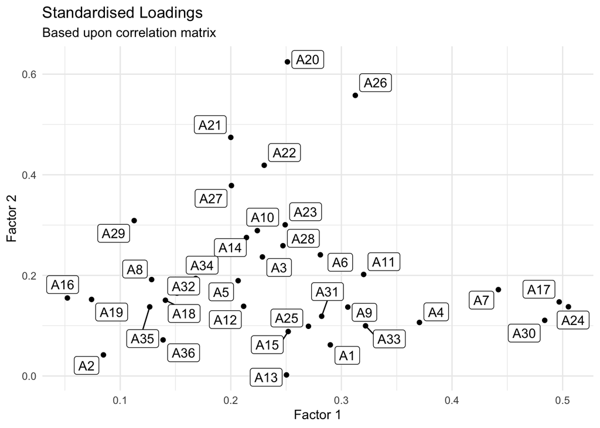

```r
load <- tidy(fitfact)

ggplot(load, aes(x = fl1, y = fl2)) +
  geom_point() +
  geom_label_repel(aes(label = paste0("A", rownames(load))), show.legend = FALSE) +
  labs(x = "Factor 1", y = "Factor 2",
       title = "Standardised Loadings",
       subtitle = "Based upon correlation matrix") +
  theme_minimal()
```

## Multidimensional Item Response Theory, including class

Do students from different programmes of study have different distributions of ability?

```r
# produce list of all the relevant file names
# (match only the courses beginning 401, i.e. exclude "all.csv")
files <- dir_ls("data", recurse = TRUE, regexp = "401.*.csv")

# read all files and add a column called file_path to identify them
eth_entry_test <- vroom(files, id = "file_path")

# parse file_path column into year and class
eth_entry_test <- eth_entry_test %>%
  mutate(
    file_path = str_remove(file_path, "data/"),
    file_path = str_remove(file_path, ".csv"),
    ) %>%
  separate(file_path, c("year", "class"), sep = "/")

# fit IRT model
fit_2pl <- mirt(
  eth_entry_test[3:38],  # all but the year and class columns
  model = 1,             # number of factors to extract
  itemtype = "2PL",      # 2 parameter logistic model
  SE = TRUE              # estimate standard errors
  )
```

```
##
Iteration: 1, Log-Lik: -85250.363, Max-Change: 0.82374
Iteration: 2, Log-Lik: -83714.765, Max-Change: 0.37956
Iteration: 3, Log-Lik: -83535.988, Max-Change: 0.17218
Iteration: 4, Log-Lik: -83473.241, Max-Change: 0.09242
Iteration: 5, Log-Lik: -83442.310, Max-Change: 0.06845
Iteration: 6, Log-Lik: -83425.490, Max-Change: 0.05833
Iteration: 7, Log-Lik: -83416.100, Max-Change: 0.03700
Iteration: 8, Log-Lik: -83410.552, Max-Change: 0.02708
Iteration: 9, Log-Lik: -83407.196, Max-Change: 0.02090
Iteration: 10, Log-Lik: -83402.119, Max-Change: 0.00403
Iteration: 11, Log-Lik: -83401.998, Max-Change: 0.00347
Iteration: 12, Log-Lik: -83401.919, Max-Change: 0.00292
Iteration: 13, Log-Lik: -83401.792, Max-Change: 0.00198
Iteration: 14, Log-Lik: -83401.775, Max-Change: 0.00117
Iteration: 15, Log-Lik: -83401.765, Max-Change: 0.00104
Iteration: 16, Log-Lik: -83401.737, Max-Change: 0.00033
Iteration: 17, Log-Lik: -83401.736, Max-Change: 0.00037
Iteration: 18, Log-Lik: -83401.735, Max-Change: 0.00031
Iteration: 19, Log-Lik: -83401.731, Max-Change: 0.00023
Iteration: 20, Log-Lik: -83401.731, Max-Change: 0.00018
Iteration: 21, Log-Lik: -83401.730, Max-Change: 0.00018
Iteration: 22, Log-Lik: -83401.730, Max-Change: 0.00016
Iteration: 23, Log-Lik: -83401.730, Max-Change: 0.00015
Iteration: 24, Log-Lik: -83401.730, Max-Change: 0.00014
Iteration: 25, Log-Lik: -83401.729, Max-Change: 0.00012
Iteration: 26, Log-Lik: -83401.729, Max-Change: 0.00011
Iteration: 27, Log-Lik: -83401.729, Max-Change: 0.00010
Iteration: 28, Log-Lik: -83401.729, Max-Change: 0.00010
##
## Calculating information matrix...
```

```r
# augment data with factor scores from model fit
eth_entry_test <- eth_entry_test %>%
  mutate(F1 = fscores(fit_2pl, method = "EAP"))
```

### Differences between years

Compare the distribution of abilities in the two years.

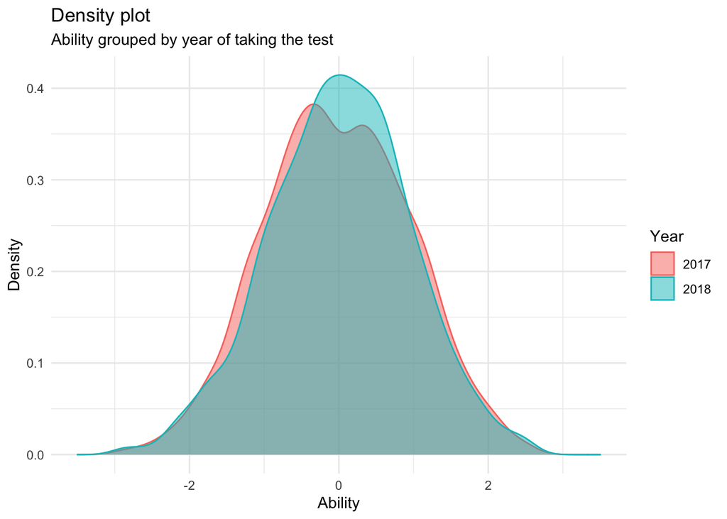

```r
ggplot(eth_entry_test, aes(F1, fill = as.factor(year), colour = as.factor(year))) +
  geom_density(alpha=0.5) +
  scale_x_continuous(limits = c(-3.5,3.5)) +
  labs(title = "Density plot",
       subtitle = "Ability grouped by year of taking the test",
       x = "Ability", y = "Density",
       fill = "Year", colour = "Year") +
  theme_minimal()
```

There does not seem to be a big difference between the two year groups, so we combine them in the following analysis.

### Differences between classes

Compare the distribution of abilities in the various classes.

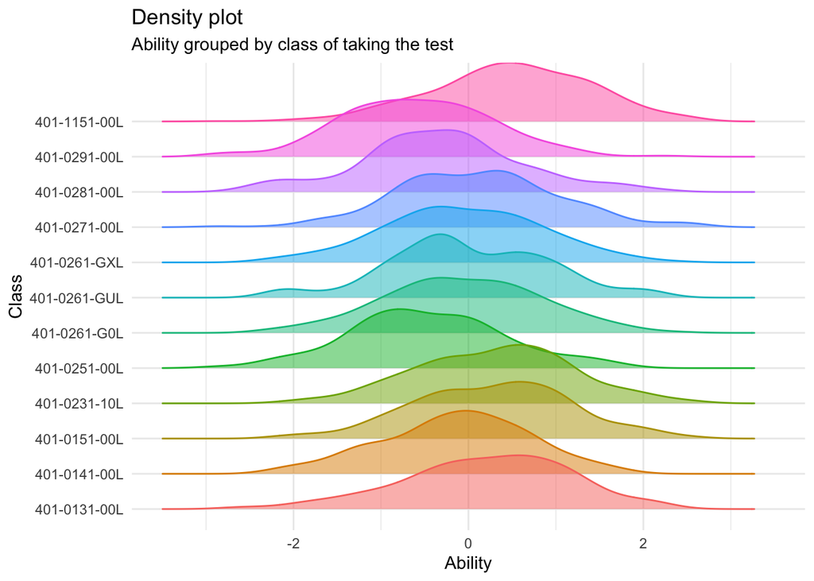

```r
ggplot(eth_entry_test, aes(x = F1, y = class, colour = class, fill = class)) +
  geom_density_ridges(alpha = 0.5) +
  scale_x_continuous(limits = c(-3.5,3.5)) +
  guides(fill = FALSE, colour = FALSE) +
  labs(title = "Density plot",
       subtitle = "Ability grouped by class of taking the test",
       x = "Ability", y = "Class") +
  theme_minimal()
```